# STOR 767 Spring 2019 Hw4: Computational Part

Zhenghan Fang

**Instruction.**

- For homework submission and grading, edit this document and create a PDF file to print and submit in class. Codes and key results should be displayed.

**Exercise 1.**

Generate training data.

```r
x = runif(100,0,1)
e = rnorm(100)
y = sin(12*(x + 0.2))/(x+0.2) + e
```

Generate test data.

```r
x.te = runif(10000,0,1)
x.te = sort(x.te)
e.te = rnorm(10000)
y.te = sin(12*(x.te + 0.2))/(x.te+0.2)
```

Polynomial (cubic) regression.

```r
fit = lm(y~bs(x,degree=3))
summary(fit)
```

```
##
## Call:
## lm(formula = y ~ bs(x, degree = 3))
##
## Residuals:
##     Min      1Q  Median      3Q     Max
## -2.8918 -1.0468 -0.0307  1.0573  3.2449
##
## Coefficients:
##                    Estimate Std. Error t value Pr(>|t|)
## (Intercept)          0.5474     0.5865   0.933   0.3530
## bs(x, degree = 3)1  -2.7553     1.6272  -1.693   0.0936 .
## bs(x, degree = 3)2   0.1326     0.9696   0.137   0.8915
## bs(x, degree = 3)3  -0.4329     0.8332  -0.520   0.6046
## ---
## Signif. codes:  0 '***' 0.001 '**' 0.01 '*' 0.05 '.' 0.1 ' ' 1
##
## Residual standard error: 1.434 on 96 degrees of freedom
## Multiple R-squared:  0.05255,    Adjusted R-squared:  0.02295
## F-statistic: 1.775 on 3 and 96 DF,  p-value: 0.1571
```

MSE (mean square error) of polynomial regression is

```r
pred.poly = predict(fit, data.frame(x=x.te))
mean((pred.poly - y.te)^2)
```

```
## [1] 1.584168
```

B-spline.

```r
fit = lm(y~bs(x,df=7,degree=3))
summary(fit)
```

```
##
## Call:
## lm(formula = y ~ bs(x, df = 7, degree = 3))
##
## Residuals:
##      Min       1Q   Median       3Q      Max
## -2.42997 -0.56604  0.02057  0.57508  2.09213
##
## Coefficients:
##                            Estimate Std. Error t value Pr(>|t|)
## (Intercept)                  3.5627     0.5554   6.415 6.01e-09 ***
## bs(x, df = 7, degree = 3)1  -5.0611     1.0891  -4.647 1.12e-05 ***
## bs(x, df = 7, degree = 3)2  -6.8452     0.7073  -9.677 1.09e-15 ***
## bs(x, df = 7, degree = 3)3   0.2122     0.9135   0.232   0.8169
## bs(x, df = 7, degree = 3)4  -5.3669     0.7738  -6.936 5.49e-10 ***
## bs(x, df = 7, degree = 3)5  -4.2728     0.8620  -4.957 3.25e-06 ***
## bs(x, df = 7, degree = 3)6  -2.2683     0.8751  -2.592   0.0111 *
## bs(x, df = 7, degree = 3)7  -3.0960     0.7502  -4.127 8.07e-05 ***
## ---
## Signif. codes:  0 '***' 0.001 '**' 0.01 '*' 0.05 '.' 0.1 ' ' 1
##
## Residual standard error: 0.924 on 92 degrees of freedom
## Multiple R-squared:  0.6232, Adjusted R-squared:  0.5946
## F-statistic: 21.74 on 7 and 92 DF,  p-value: < 2.2e-16
```

MSE of B-spline is

```r
pred.bs = predict(fit, data.frame(x=x.te))
mean((pred.bs - y.te)^2)
```

```
## [1] 0.08277361
```

Natural cubic spline.

```r
fit = lm(y~ns(x,df=7))
summary(fit)
```

```
##
## Call:
## lm(formula = y ~ ns(x, df = 7))
##
## Residuals:
##      Min       1Q   Median       3Q      Max
## -2.44616 -0.61210  0.04409  0.53005  2.15650
##
## Coefficients:
##                Estimate Std. Error t value Pr(>|t|)
## (Intercept)      3.2644     0.4481   7.285 1.07e-10 ***
## ns(x, df = 7)1  -2.5105     0.6123  -4.100 8.90e-05 ***
## ns(x, df = 7)2  -1.2292     0.8827  -1.393 0.167127
## ns(x, df = 7)3  -3.7092     0.6842  -5.421 4.73e-07 ***
## ns(x, df = 7)4  -4.8915     0.7063  -6.926 5.76e-10 ***
## ns(x, df = 7)5  -0.7336     0.5514  -1.330 0.186721
## ns(x, df = 7)6  -8.7744     1.0982  -7.990 3.78e-12 ***
## ns(x, df = 7)7   1.6093     0.4699   3.425 0.000921 ***
## ---
## Signif. codes:  0 '***' 0.001 '**' 0.01 '*' 0.05 '.' 0.1 ' ' 1
##
## Residual standard error: 0.9114 on 92 degrees of freedom
## Multiple R-squared:  0.6335, Adjusted R-squared:  0.6056
## F-statistic: 22.71 on 7 and 92 DF,  p-value: < 2.2e-16
```

MSE of natural cubic spline is

```r
pred.ns = predict(fit, data.frame(x=x.te))
mean((pred.ns - y.te)^2)
```

```
## [1] 0.1148101
```

Smoothing spline (using ‘generalized’ cross-validation).

```r
fit = smooth.spline(x,y)
fit
```

```
## Call:
## smooth.spline(x = x, y = y)
##
## Smoothing Parameter  spar= 0.7450103  lambda= 0.0003324572 (12 iterations)
## Equivalent Degrees of Freedom (Df): 9.204211
## Penalized Criterion (RSS): 75.9465
## GCV: 4.493219
```

```r
summary(fit)
```

```
##            Length Class             Mode
## x          100    -none-            numeric
## y          100    -none-            numeric
## w          100    -none-            numeric
## yin        100    -none-            numeric
## tol          1    -none-            numeric
## data         3    -none-            list
## no.weights   1    -none-            logical
## lev        100    -none-            numeric
## cv.crit      1    -none-            numeric
## pen.crit     1    -none-            numeric
## crit         1    -none-            numeric
## df           1    -none-            numeric
## spar         1    -none-            numeric
## ratio        1    -none-            numeric
## lambda       1    -none-            numeric
## iparms       5    -none-            numeric
## auxM         0    -none-            NULL
## fit          5    smooth.spline.fit list
## call         3    -none-            call
```

MSE of smoothing spline is

```r
pred.smooth = predict(fit,x.te)
mean((pred.smooth$y - y.te)^2)
```

```
## [1] 0.1270302
```

Local polynomial regression with Gaussian kernel.

```r
fit.loc.gauss = locfit(y~x, data.frame(x=x,y=y), kern='gauss')
summary(fit.loc.gauss)
```

```
## Estimation type: Local Regression
##
## Call:
## locfit(formula = y ~ x, data = data.frame(x = x, y = y), kern = "gauss")
##
## Number of data points:  100
## Independent variables:  x
## Evaluation structure: Rectangular Tree
## Number of evaluation points:  5
## Degree of fit:  2
## Fitted Degrees of Freedom:  4.132
```

MSE of local polynomial regression with Gaussian kernel is

```r
pred.loc.gauss = predict(fit.loc.gauss, data.frame(x=x.te))
mean((pred.loc.gauss - y.te)^2)
```

```
## [1] 0.8837841
```

Local polynomial regression with tricube kernel.

```r
fit.loc.tricube = locfit(y~x, data.frame(x=x,y=y), kern='tcub')
summary(fit.loc.tricube)
```

```
## Estimation type: Local Regression
##
## Call:
## locfit(formula = y ~ x, data = data.frame(x = x, y = y), kern = "tcub")
##
## Number of data points:  100
## Independent variables:  x
## Evaluation structure: Rectangular Tree
## Number of evaluation points:  5
## Degree of fit:  2
## Fitted Degrees of Freedom:  4.764
```

MSE of local polynomial regression with tricube kernel is

```r
pred.loc.tricube = predict(fit.loc.tricube, data.frame(x=x.te))
mean((pred.loc.tricube - y.te)^2)
```

```
## [1] 0.7271918
```

Plot the fitting results.

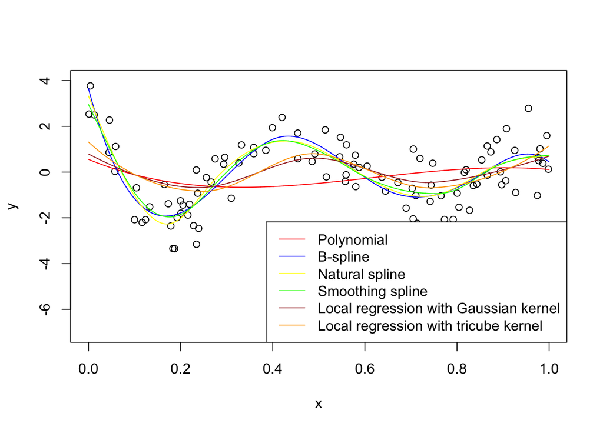

```r
plot(x, y, ylim=c(-7,4))
lines(x.te, pred.poly, col = 'red')
lines(x.te, pred.bs, col = 'blue')
lines(x.te, pred.ns, col = 'yellow')
lines(x.te, pred.smooth$y, col = 'green')
lines(x.te, pred.loc.gauss, col = 'brown')
lines(x.te, pred.loc.tricube, col = 'orange')
legend("bottomright",c('Polynomial','B-spline','Natural spline','Smoothing spline','Local regression with Gaussian kernel','Local regression with tricube kernel'), lty = c(1), col = c('red','blue','yellow','green','brown','orange'))
```

**Exercise 2.**

Load data.

```r
zip.train = read.csv('zip.train.gz', header = F, sep=" ")
zip.test = read.csv('zip.test.gz', header = F, sep=" ")
zip.train = zip.train[, -258]
zip.train = zip.train[which(zip.train$V1==3 | zip.train$V1==8), ]
zip.test = zip.test[which(zip.test$V1==3 | zip.test$V1==8), ]
N.3 = length(which(zip.train$V1==3))
N.8 = length(which(zip.train$V1==8))
N.test = dim(zip.test)[1]
```

Generate a Gaussian radial basis function kernel.

```r
rbf <- rbfdot(sigma = 0.05)
```

Define function “locLda” for local LDA, which returns the logit for the test sample “test” using training data “zip.train” and kernel function “kernel”.

```r
locLda = function(zip.train, test, kernel){

  # compute weights for training samples
  weight = kernelMatrix(kernel, data.matrix(zip.train[,-1]), data.matrix(test))

  # compute centers and covariance by weighted average
  t = cov.wt(zip.train[which(zip.train$V1==3), -1], weight[which(zip.train$V1==3)])
  mu.3 = data.matrix(t$center)
  cov.3 = t$cov
  t = cov.wt(zip.train[which(zip.train$V1==8), -1], weight[which(zip.train$V1==8)])
  mu.8 = data.matrix(t$center)
  cov.8 = t$cov
  cov.all = (cov.3 * N.3 + cov.8 * N.8) / (N.3+N.8 - 2)

  # compute prior probablity of classes by weighted average
  pi.3 = sum(weight[which(zip.train$V1==3)]) / sum(weight)
  pi.8 = sum(weight[which(zip.train$V1==8)]) / sum(weight)

  # compute inverse of covariance matrix
  cov.all.inv = solve(cov.all)

  # compute the logit
  logit = log(pi.3/pi.8) - 0.5 * t(mu.3 + mu.8) %*% cov.all.inv %*% (mu.3 - mu.8) + data.matrix(test) %*% cov.all.inv %*% (mu.3 - mu.8)

  return(logit)
}
```

Apply local LDA with Gaussian radial basis function kernel. The test error rate is

```r
logit = c()
for (k in c(1:N.test)){
  logit[k] = locLda(zip.train, zip.test[k,-1], rbf)
}
pred = factor(3*(logit > 0) + 8*(logit <= 0))
err = sum(pred != zip.test$V1) / N.test
err
```

```
## [1] 0.03012048
```

Apply local LDA with Polynomial kernel. The test error rate is

```r
poly <- polydot(degree = 2)
logit = c()
for (k in c(1:N.test)){
  logit[k] = locLda(zip.train, zip.test[k,-1], poly)
}
pred = factor(3*(logit > 0) + 8*(logit <= 0))
err = sum(pred != zip.test$V1) / N.test
err
```

```
## [1] 0.04216867
```

**Exercise 3.**

Load data. Select samples of the phonemes “aa” and “ao”. Randomly select 1000 training samples.

```r
phoneme = read.csv('phoneme.data')
phoneme = phoneme[which(phoneme$g=='aa' | phoneme$g=='ao'),]
phoneme = phoneme[,2:258]
train = sample(c(1:1717))[1:1000]
```

Filter the inputs by bases of natural cubic splines (degree of freedom = 12).

```r
phoneme.matrix = data.matrix(phoneme[,1:256])
basis = ns(c(1:256), df=12)
x.filtered = phoneme.matrix %*% basis
```

Fit coefficients $\theta$ on filtered inputs by logistic regression.

```r
phoneme.filtered = data.frame(x.filtered)
phoneme.filtered$g = factor(phoneme$g)
fit.restricted = glm(g~., data=phoneme.filtered, family = binomial(link = "logit"), subset = train)
theta.restricted = basis %*% fit.restricted$coefficients[2:13]
```

Fit $\theta$ on raw inputs.

```r
fit.raw = glm(g~., data=phoneme, family = binomial(link = "logit"), subset = train)
theta.raw = fit.raw$coefficients[2:257]
```

Plot the coefficients obtained from raw (gray) and filtered (red) data as a function of frequency (i.e. Figure 5.5 in textbook).

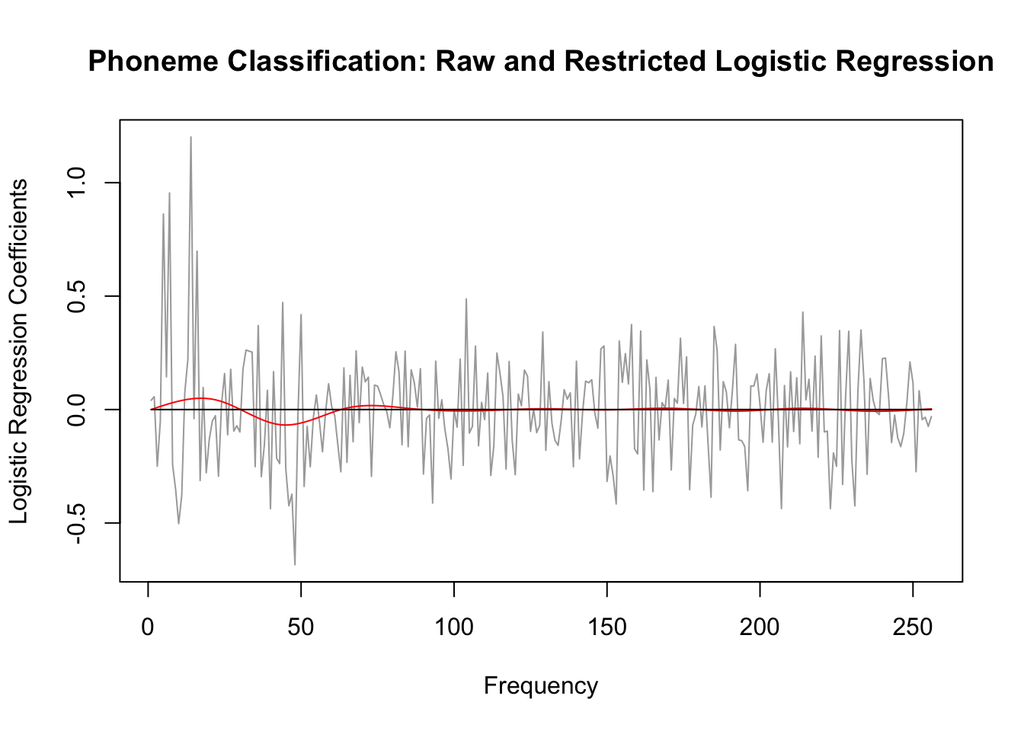

```r
plot(c(1:256), theta.raw, type='l', col = "dark gray", xlab='Frequency', ylab='Logistic Regression Coefficients', main='Phoneme Classification: Raw and Restricted Logistic Regression')
lines(c(1:256), theta.restricted, col = "red")
lines(c(1:256), rep(0,256), col = "black")
```

Quadratic discriminant analysis (QDA).

Set five degrees of freedom: 6, 9, 12, 15, 18. Because intercept is not included, the corresponding numbers of knots are 7, 10, 13, 16, 19.

```r
df.cv = c(6,9,12,15,18)
```

Use cross validation to select the best degree of freedom. Define error as the proportion of misclassified samples. The cross-validation errors for different degrees of freedom are

```r
i=1
err=c()
for (df.i in df.cv){
  basis = ns(c(1:256), df=df.i)
  x.filtered = phoneme.matrix %*% basis

  phoneme.filtered = data.frame(x.filtered)
  phoneme.filtered$g = factor(phoneme$g)

  fit.qda.cv = qda(g~., data=phoneme.filtered, subset=train, CV=TRUE)
  err[i] = sum(fit.qda.cv$class != phoneme.filtered$g[train])/1000
  i=i+1
}
err
```

```
## [1] 0.241 0.226 0.210 0.207 0.210
```

Select the degree of freedom that yields the lowest error (15, error = 0.207). The test error of QDA is

```r
basis = ns(c(1:256), df=df.cv[which(err == min(err))])
x.filtered = phoneme.matrix %*% basis
phoneme.filtered = data.frame(x.filtered)
phoneme.filtered$g = factor(phoneme$g)

fit.qda = qda(g~., data=phoneme.filtered, subset=train)

pred.qda = predict(fit.qda, phoneme.filtered[-train,])
sum(pred.qda$class != phoneme.filtered$g[-train])/717
```

```
## [1] 0.2022315
```